# Labo 3 Multivariate statistics II

#### Objectives

Visualize bivariate data and show the relationships between variables. Test relationships between different types of variables and draw reasonable conclusions from the analysis The overall goal of the lab will be to analyze this data in order to determine if we can make certain assumptions about the variables (normality, uniform distribution…), if there are potential biases in the dataset that we should be aware of, and if we can find some interesting relationships either between the independent variables, or between the outcome variable and some of the independent variables.

`NB :` even though we are not going to be working on a classifier at the moment, we will still separate the data into a training set and a test set. This is because we will try to do classification at some point, and we don’t want to make choices on the classification method based on conclusions that we made using the full dataset!

## Exercice 1

**Check the distribution of values for the nominal variables.**

- **Identify variables:** From the description of the variable, determine which ones should ideally have equal frequencies of values in an unbiased dataset. For example, in a medical dataset, variables like "gender" might be expected to have roughly equal representation.
- **Propose visualizations:**
  - **Bar charts:** Effective for visualizing the frequency of each category within a nominal variable.
  - **Pie charts:** Can also be used to show the proportion of each category, but bar charts are generally preferred for easier comparison.

**Use the appropriate statistical test to determine if those variables have equal frequencies of values.**

- **Chi-square test of goodness-of-fit:** This test compares the observed frequencies of each category in the data to the expected frequencies under the assumption of a uniform distribution (equal frequencies for all categories).
- **Interpretation:** If the p-value from the chi-square test is statistically significant (typically p < 0.05), it suggests that the observed frequencies deviate significantly from a uniform distribution, indicating potential bias in the dataset.

**Conclude on dataset bias and limitations:**

- **Unbiased dataset:** If the chi-square test does not reject the null hypothesis (uniform distribution) for the relevant nominal variables, it suggests that the dataset is relatively unbiased with respect to those variables.
- **Biased dataset:** If the chi-square test indicates significant deviations from a uniform distribution for certain nominal variables, the dataset may be biased.
- **Limitations:**
  - **Bias can impact model performance:** A biased dataset can lead to models that perform poorly on unseen data, especially if the bias in the training data does not reflect the true distribution in the real world.
  - **Misleading conclusions:** Analyzing a biased dataset can lead to misleading conclusions about the relationships between variables and the overall phenomenon being studied.

**Check the distribution of value for the numerical variables.**

- **Visualizations:**
  - **Histograms:** To visually inspect the shape of the distribution of each numerical variable.
  - **QQ plots (Quantile-Quantile plots):** To compare the distribution of the data to a theoretical distribution (e.g., normal distribution).

**Hypotheses and statistical tests:**

- **Normality:**
  - **Hypothesis:** The numerical variable follows a normal distribution.
  - **Test:** Shapiro-Wilk test
- **Uniformity:**
  - **Hypothesis:** The numerical variable follows a uniform distribution.
  - **Test:** Kolmogorov-Smirnov test

**Interpret test results:**

- **Reject the null hypothesis:** If the p-value from the test is statistically significant, reject the hypothesis that the data follows the assumed distribution (normal or uniform).
- **Accept the null hypothesis:** If the p-value is not statistically significant, there is not enough evidence to reject the hypothesis that the data follows the assumed distribution.

**Implications:**

- **Normality assumptions:** Many statistical methods and machine learning algorithms assume that the data is normally distributed. Deviations from normality can affect the validity of these methods and the accuracy of the results.
- **Uniformity assumptions:** Some statistical tests and models rely on the assumption of uniformly distributed data. Violations of this assumption can lead to inaccurate inferences.

The alzheimer.py file contains two helper classes to help you process the data. Here is a quick example showing how to split the data into a training and test set, and how to retrieve the values for a specific variable:

```
dataset = AlzheimerDataset("alzheimers_disease_data.csv") # put the path to the CSV file here
# set a random state for replicability between your experiments
train_data, test_data = dataset.random_split(test_ratio=0.2, random_state=0)
values = train_data["Diabetes"]
# get the labels for the possible values
labels = train_data.labels("Diabetes")
# print the count per value for the Diabetes variable
print([(labels[v], (values==v).sum()) for v in np.unique(values)])
# note that this is a shorter way of writing:
for v in np.unique(values):
    print(labels[v], (values==v).sum())
# get a pandas.DataFrame with all nominal variables:
cats = train_data.nominals
# get a pandas.DataFrame with all the numerical variables:
nums = train_data.numericals
```

[output not shown]

[output cut: 69 more lines]

```
  L'hypothèse d'uniformité est rejetée pour MMSE.
Analyse pour FunctionalAssessment :
  Moyenne : 5.80
  Écart-type : 2.92
  Test de Shapiro-Wilk (normalité) - p-valeur : 0.0000
  Test de Kolmogorov-Smirnov (uniformité) - p-valeur : 0.0000
  L'hypothèse de normalité est rejetée pour FunctionalAssessment.
  L'hypothèse d'uniformité est rejetée pour FunctionalAssessment.
Analyse pour ADL :
  Moyenne : 4.95
  Écart-type : 2.93
  Test de Shapiro-Wilk (normalité) - p-valeur : 0.0000
  Test de Kolmogorov-Smirnov (uniformité) - p-valeur : 0.0000
  L'hypothèse de normalité est rejetée pour ADL.
  L'hypothèse d'uniformité est rejetée pour ADL.
```

## Exercise 2: Testing Relationships Between Independent Variables

**Objectives:**

- Test the potential relationships between independent variables.

**Selecting Appropriate Tests:**

- **Numerical vs Numerical:**
  - **Pearson correlation coefficient:** Suitable for linear relationships between two continuous variables.
  - **Spearman correlation coefficient:** Suitable for monotonic relationships (not necessarily linear) between two variables, including ordinal variables.
- **Categorical vs Categorical:**
  - **Chi-square test of independence:** Determines if there is a statistically significant association between two categorical variables.
  - **McNemar's test:** Used to compare the proportions of two related categorical variables in paired data.
- **Categorical vs Numerical:**
  - **T-test:** Used to compare the means of a numerical variable between two groups defined by a categorical variable.
  - **ANOVA (Analysis of Variance):** Used to compare the means of a numerical variable across multiple groups defined by a categorical variable.
  - **Non-parametric tests (e.g., Mann-Whitney U test, Kruskal-Wallis test):** Used when the assumptions of parametric tests (like normality) are not met.

**Multiple Comparisons Problem:**

- When conducting multiple statistical tests, the probability of obtaining a statistically significant result by chance increases.
- This is known as the **multiple comparisons problem**.
- To address this, you can adjust the significance level (alpha) using methods like:
  - **Bonferroni correction:** A conservative method that divides the original alpha by the number of tests.
  - **False Discovery Rate (FDR) control:** Methods like Benjamini-Hochberg control aim to control the expected proportion of false discoveries among the significant results.

**Dimensionality Reduction:**

- If you find high correlations between certain variables, it might be possible to **reduce the dimensionality** of the problem.
- This can be achieved by:
  - **Merging highly correlated variables:** Combining similar variables into a single variable.
  - **Principal Component Analysis (PCA):** A technique that transforms the original variables into a new set of uncorrelated variables called principal components.

**Note:** These are general guidelines. The specific choice of test will depend on the characteristics of the data and the research question.

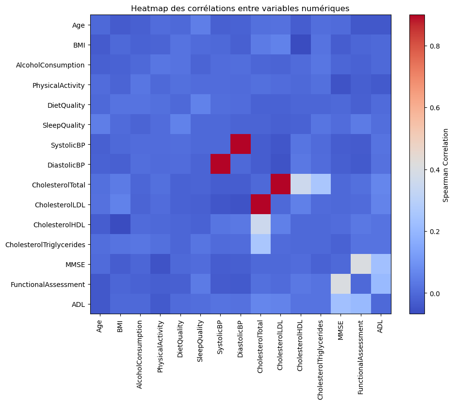

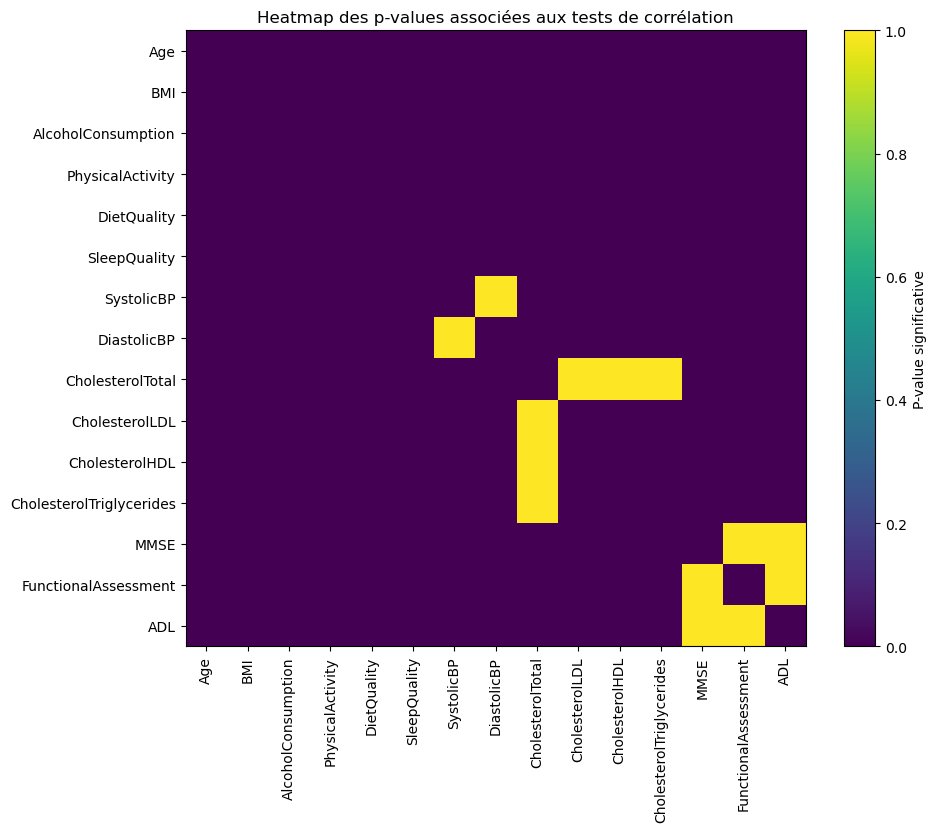

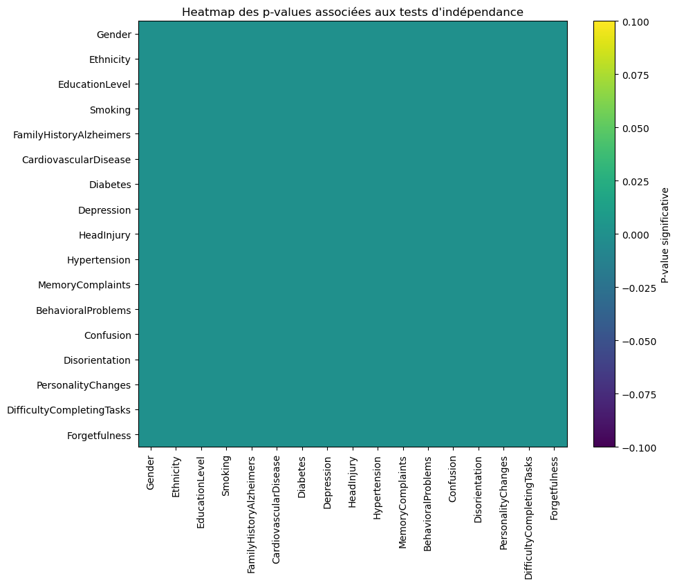

```
Analyse complétée. Consultez les heatmaps pour identifier les relations fortes entre variables.
```

## Step 3 : Analyse des relations entre variables

### Tests d'indépendance

- **Chi-deux:** Utilisé pour tester l'indépendance entre variables catégorielles.
  - **Correction de Bonferroni:** Appliquée pour ajuster le seuil de significativité face aux multiples tests.
- **Visualisation:** Heatmap pour représenter les résultats des tests.

### Réduction de dimensionnalité

- **Corrélations:** Identification de variables numériques fortement corrélées.
- **Techniques:**
  - ACP (Analyse en Composantes Principales)
  - Analyse factorielle
- **Objectif:** Réduire la dimensionnalité de l'analyse sans perte d'information significative.

### Conclusions et perspectives

**Remarque:** Les résultats détaillés (valeurs de p, heatmaps) devraient être présentés dans les annexes ou dans le corps du rapport, selon leur importance.

**Mots-clés:** test du Chi-deux, correction de Bonferroni, heatmap, ACP, réduction de dimensionnalité.

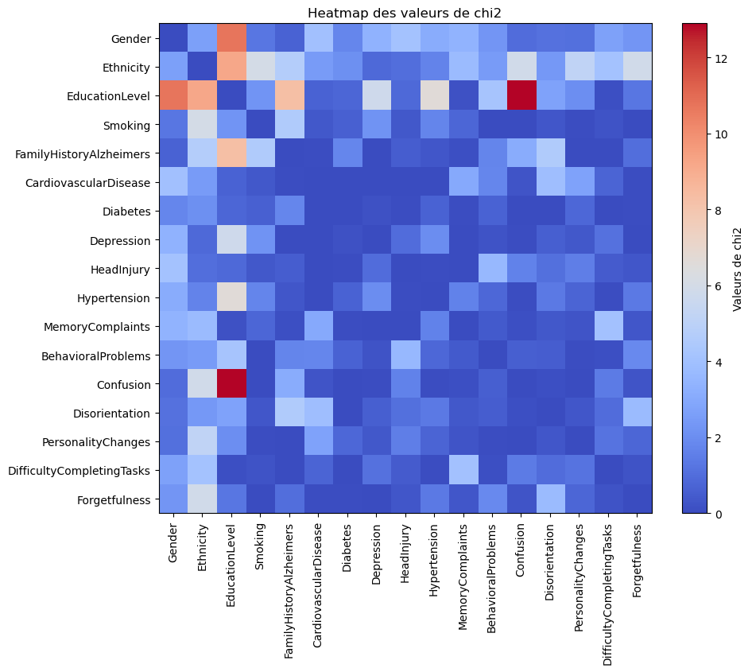

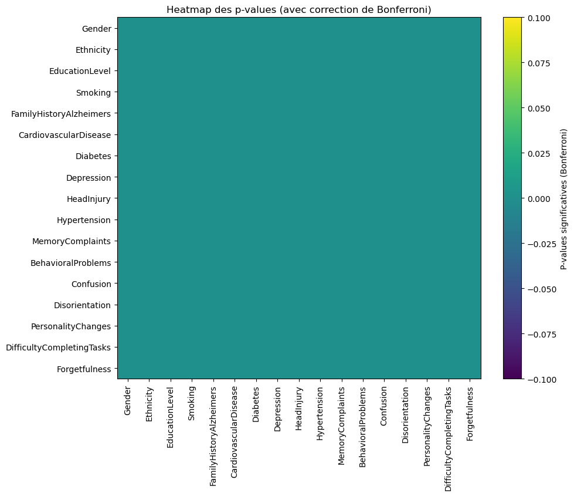

## Exercice 3 : Relation entre la variable de sortie (Diagnostic) et les variables indépendantes

**Objectif :** Identifier les variables indépendantes les plus corrélées à la variable de sortie (diagnostic) afin de sélectionner les variables pertinentes pour la modélisation.

**Méthodologie :**

- **Tests d'indépendance:**
  - **Variables catégorielles:** Test du Chi-deux pour évaluer l'association entre la variable catégorielle et la variable de sortie (diagnostic).
  - **Variables numériques:**
    - **Discrétisation:** Les variables numériques sont divisées en plusieurs groupes (10, 20, 30) pour les transformer en variables catégorielles.
    - **Test du Chi-deux:** Application du test du Chi-deux entre la variable catégorisée et la variable de sortie.
- **Correction de Bonferroni:** Application d'une correction pour ajuster le seuil de significativité afin de compenser les multiples tests réalisés.

**Résultats:**

- **Variables significatives:**
  - **Catégorielles:** MemoryComplaints, BehavioralProblems
  - **Numériques:** MMSE, FunctionalAssessment, ADL

**Conclusion:** Les variables identifiées comme étant significativement corrélées au diagnostic sont de bons candidats pour être inclus dans les modèles prédictifs. Ces variables pourraient également être utilisées pour réduire la dimensionnalité des données.

**Remarque:** Il est important de noter que la discrétisation des variables numériques peut entraîner une perte d'information. Des méthodes plus sophistiquées, comme l'analyse de corrélation pour les variables numériques, pourraient être envisagées.

**Mots-clés:** test du Chi-deux, correction de Bonferroni, variable catégorielle, variable numérique, diagnostic, réduction de dimensionnalité.

**Visualisation suggérée:**

- **Heatmap:** Pour représenter les résultats des tests du Chi-deux et visualiser les corrélations entre les variables.

**Prochaines étapes:**

- **Modélisation:** Utiliser les variables sélectionnées pour construire des modèles prédictifs (régression logistique, arbre de décision, etc.).
- **Validation:** Évaluer la performance des modèles sur un jeu de données de test.

Cette analyse permet d'identifier les facteurs les plus importants associés au diagnostic, ce qui est essentiel pour une meilleure compréhension de la maladie et pour développer des outils d'aide à la décision.

```
Variables catégorielles significatives:
- MemoryComplaints (p-value: 0.0000)
- BehavioralProblems (p-value: 0.0000)

Variables numériques significatives:

Avec 10 groupes:
- MMSE (p-value: 0.0000)
- FunctionalAssessment (p-value: 0.0000)
- ADL (p-value: 0.0000)

Avec 20 groupes:
- MMSE (p-value: 0.0000)
- FunctionalAssessment (p-value: 0.0000)
- ADL (p-value: 0.0000)

Avec 30 groupes:
- MMSE (p-value: 0.0000)
- FunctionalAssessment (p-value: 0.0000)
- ADL (p-value: 0.0000)
```

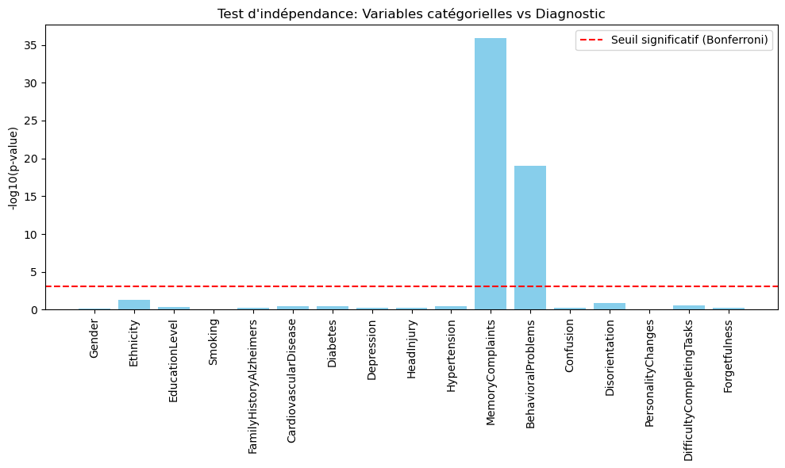

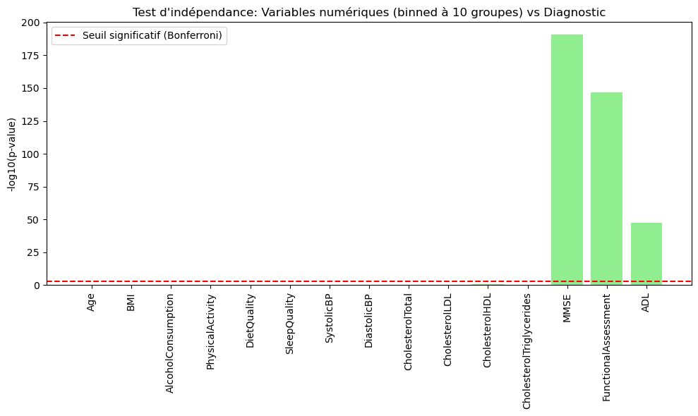